# Coursework Report

*N* removed NAs: 3

*N* removed typo: 1

*N* removed <18: 21

*N* total clean: 125

| Group | *N* | *M*<sub>age</sub> | *M*<sub>rating</sub> |
| --- | --- | --- | --- |
| Control | 61 | 20.64 | 6.58 |
| Experim | 64 | 20.48 | 5.66 |

**Main analysis results**

*t*(123) = 6.33, *p* < .001

[interactive chart not shown]

[figure not shown]

[interactive chart not shown]

# Coursework Report

Analysing Data, Spring 2020

# Methods

## Participants

Table 1 *Participant description statistics*

| Condition | *N* | *M*<sub>age</sub> | *SD*<sub>age</sub> | *MIN<sub>age</sub>* | *MAX<sub>age</sub>* |
| --- | --- | --- | --- | --- | --- |
| white | 61 | 20.64 | 2.10 | 18 | 26 |
| red | 64 | 20.48 | 1.86 | 18 | 26 |

## Design

The experiment tested the conceptual hypothesis that women perceive men to be more attractive in conjunction with the colour red. This was measured by a composite attractiveness score given by the female participants in response to the image of a man, either against a red or a white background. As this experiment is a replication of the Elliot et al.(2010) study the same materials were used, such as the 4-in. x 6-in image of a moderately attractive Caucasian man with brown hair against the white or red background. The participants viewed the image for 5 seconds and then were asked the same three questions as the original study; “How attractive do you think this person is?” “How pleasant is this person to look at?” and “If I were to meet the person in this picture face to face, I would think he is attractive.” The participants responded by rating the image on a scale from 1, extremely unattractive to 9, extremely attractive. The composite score was made up of the average scores across the three questions. The operational hypothesis for the current study is, women will rate the image of the man as more attractive when against a red background than when against a white background on a scale from 1 to 9. The statistical test used in this experiment is an independent-measures t-test as two means are being compared

# Results

Table 2 *Overall attractiveness score by condition*

| Condition | *N* | *M*<sub>attractiveness_score</sub> | *SD*<sub>attractiveness_score</sub> |
| --- | --- | --- | --- |
| white | 61 | 6.58 | 0.77 |
| red | 64 | 5.66 | 0.86 |

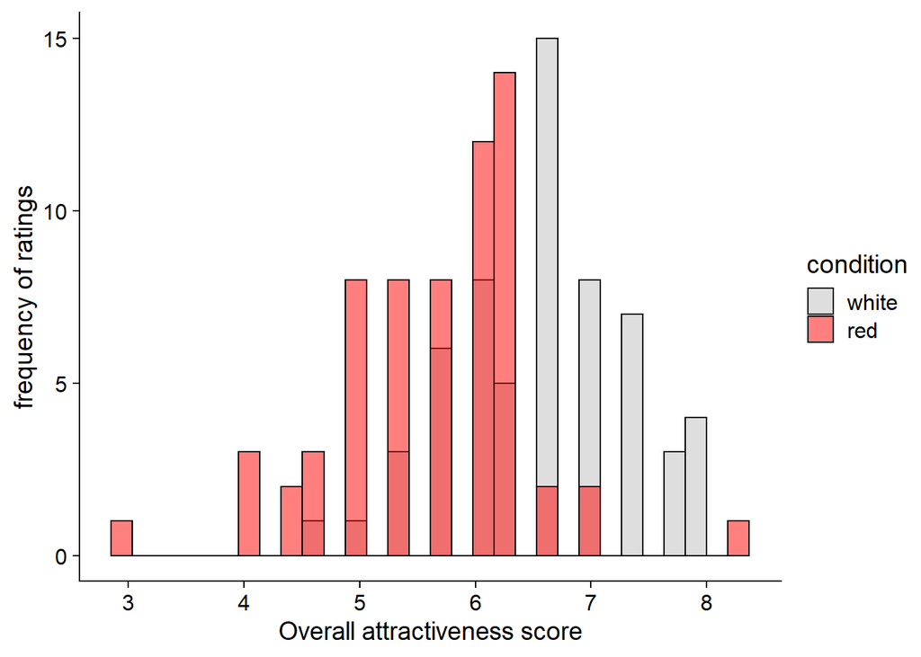

Figure 3. *Histogram of attractiveness ratings by condition.*

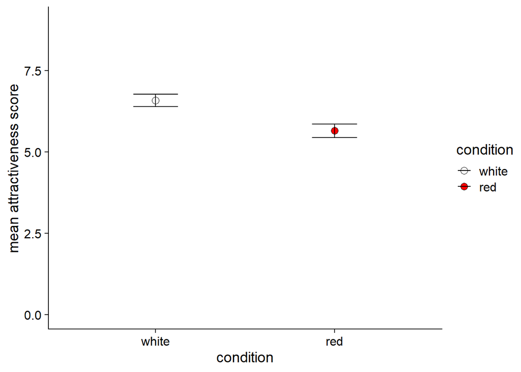

Figure 4. *Plot of the mean attractiveness score of both the red and white condition.*

# Discussion

The results of the present research show that there was no observable red effect. The experiment instead showed that those viewing the image with the white border rated the man as more attractive compared to the red. Furthermore, the statistical test employed suggests that this relationship was significant, thus contradicting the experiment’s hypothesis that the colour red elicits higher attractiveness ratings. This experiment was a replication of the Elliot et al(2010) study which found, contrary to our results, that the colour red did significantly increase attractiveness ratings compared to white. The present experiment thus provides contradicting evidence challenging the strength of the original study’s findings that there is an observable red effect, suggesting other factors may be contributing to the relationship of colour and attractiveness.

The current research was a replication of experiment 1 by Elliot et al(2010) using the same materials, despite this, no red effect was observed. One possible explanation for the disparity in results may be the small sample size used in the original study. Experiment 1 of the origional study only used 21 participants and while 7 more experiments were carried out, they all used small samples. In contrast, this study used 125 participants, therefore, the results may be more representative of the true effect in the population. The issue with the use of a small sample size is that they have less statistical power and are less likely to represent the true parameters in the target population. Evidence that the original study may have overstated the red effect in the population comes from Peperkoorn et al(2016). In this study there was no significant red effect over 3 experiments when using much larger samples; for example, experiment 1 used 204 participants, a much larger sample than the Elliot et al(2010) study. Both the current research and the Peperkoorn et al study shed doubt on the reproducibility of the red effect and its possible presence in the population.

Notwithstanding a possible explanation for the experiment failing to reproduce the red effect may be the underlying factors facilitating the red effect not being controlled. One possible moderator of the red effect in women’s rating of male attractiveness is the influence of their menstrual cycle. Studies have found a significant red effect only in participants at a high risk of conception with no significant relationship found for participants at low risk of conception (Prokop et al., 2015). This study, therefore, suggests that women’s mensural cycles may influence attractiveness ratings when viewing the colour red. Participants menstrual cycle was not controlled in the present study, therefore, it may be a confounding variable affecting results. That being said, the female participants were randomly assigned between the two conditions, therefore, is unlikely that all women at a high/low risk of conception would be together in one condition.

An alternative moderator of the red effect which should be considered is the initial attractiveness of the target person. One study found a moderately significant relationship between the colour red and women rating of sexual attractiveness only when viewing a masculine male face but not when viewing a feminine one (Wen et al., 2014). This suggests that the original attractiveness and masculinity of the man in the image is of vital importance and could have a significant impact on observing the red effect. The image used in this study, however, was the same used in the Elliot et al(2010) study which was previously rated as moderately attractive by an independent sample. It may be necessary however, to replace the original image with one rated as moderately attractive by a larger independent sample as the sample used in the original study was very small and conducted 10 years ago.

A Further limitation to the presented study which must be acknowledged was that participants were only aged 18 to 26. The participants therefore only represent one subset of the whole female population preventing any conclusions to be generalised to the wider population. The main issue with only recording one age group is what this age range deems attractive may be different from older participants. This is a common issue in research into the red effect with many studies such as the Elliott et al 2010 study predominantly using university undergraduate aged participants. An additional issue facing all research into the red effect is that the exact colour of the red may lead to different associations (Wen et al., 2014). Wen et al(2014) argued if the red is of a certain hue or saturation which is associated with increased aggression or other unappealing personality types in males, it may result in perceived unattractiveness. This may explain why the current research saw an increase of attractiveness in the white condition which is not attributed to such behaviours.

An area of research which may be of interest to the literature on the red effect may be the effect of red on the wearer. Status (Elliot et al., 2010) and biology (Prokop et al., 2015) have previously been used to explain the red effect, however, an alternative explanation may be the effect on the wearer. The colour red may, for example, increase the wearer’s confidence, in turn, making them more attractive to the observer. Roberts et al(2010) provides evidence for this; the researchers presented the participants with either an original image of a man wearing a white shirt or one where the man had originally been wearing a red shirt which had been digitally changed to white. While the participants saw the man as wearing a white shirt in both conditions, they rated the man who had originally been wearing red as more attractive. This, therefore, illustrates how the red effect can be observed even if the participants never see the red cue, thus suggesting the effect of red on the wearer may be more important than on the observer. This may be an interesting area for future research, looking into the wearer’s behaviour and self-esteem in relation to the colour of their clothes or surroundings they are in.

To conclude the present study did not find red to significantly increase female attractiveness ratings rather it found a significant effect of white on the attractiveness rating of the man. This study, therefore, failed to replicate the findings of the original study(Elliot et al., 2010) contradicting the hypothesis that there is a red effect. Notwithstanding, the effect of colour on attraction still warrants further research and remains an interesting area of study. Future research should aim to uncover the underlying mechanisms moderating the effect of colour on both the wearer and observers in order to develop a more comprehensive understanding.

# References

Elliot, A. J., Niesta Kayser, D., Greitemeyer, T., Lichtenfeld, S., Gramzow, R. H., Maier, M. A., & Liu, H. (2010). Red, rank, and romance in women viewing men. Journal of Experimental Psychology: General, 139(3), 399–417. http://dx.doi.org/10.1037/a0019689

Peperkoorn, L. S., Roberts, S. C., & Pollet, T. V. (2016). Revisiting the Red Effect on Attractiveness and Sexual Receptivity: No Effect of the Color Red on Human Mate Preferences. Evolutionary Psychology, 14(4), 1474704916673841. https://doi.org/10.1177/1474704916673841

Prokop, P., Pazda, A. D., & Elliot, A. J. (2015). Influence of conception risk and sociosexuality on female attraction to male red. Personality and Individual Differences, 87, 166–170. https://doi.org/10.1016/j.paid.2015.07.042

Roberts, S. C., Owen, R. C., & Havlicek, J. (2010). Distinguishing between Perceiver and Wearer Effects in Clothing Color-Associated Attributions. Evolutionary Psychology, 8(3), 147470491000800320. https://doi.org/10.1177/147470491000800304

Wen, F., Zuo, B., Wu, Y., Sun, S., & Liu, K. (2014). Red is Romantic, but Only for Feminine Females: Sexual Dimorphism Moderates Red Effect on Sexual Attraction. Evolutionary Psychology, 12(4), 147470491401200420. https://doi.org/10.1177/147470491401200404